# Automated Reports InDiKo

Function Overview

Author

Marc Sparhuber, Sonja Hahn

## **Introduction**

> This file is the result of efforts to automatise the creation of recurring evaluations at a higher education institution. The following functions have been used to provide feedback for single workshops and lectures containing a single measurement time point, but also pre- and post-tests. Feel free to use the code for your demands! We are open for feedback on the code and work on a package including these functions is in progress.

> To provide an example of the function’s capabilities, we use some random data and item labels from the technological knowledge scale which we adapted to German (Schmidt et al. 2009).

## **Necessary Libraries**

```r
library(knitr)
library(tidyverse)
library(psych)
library(gluedown)
library(patchwork)
library(stringi)
library(grid)
library(haven)
```

## **Example data**

```r
dsw <- readRDS("Quartodata.rds")
dsw
```

```
   TK_mean t PersonID.m TK1 TK2
1     3.75 0 GNZuCtwed3   3   2
2     4.25 0 CAgNlUizNm   3   3
3     4.00 0 vDe7GN0NrL   4   1
4     3.50 0 TbUBpfn6iP   3   2
5     4.00 0 oemYWm1Tjg   3   3
6     4.25 0 TrRF46JWfP   4   2
7     2.75 0 uISKeFTl5s   4   3
8     3.75 0 LqLKTtrOmx   3   2
9     4.00 0 QiOKkCi7F8   3   3
10    4.00 0 E3dsmnSPob   5   1
11    3.75 0 eLGzdD8Tvb   1   4
12    3.00 0 yjMQ90i6Rd   3   1
13    3.50 0 zUUAkSVCEa   5   3
14    4.25 0 Z42dvbYWzV   1   3
```

[output cut: 26 more lines]

## **Functions**

### Open ended answers

> To show the capabilities of the open answers function we add a few fictional strings to our data, similary to how they may look when extracted from an open answers field in a survey. These include common writing patterns we have encountered, such as starting a new sub-section of a comment with a hyphen or a line break. The open answers function is made to display such comments closely to how they were written by the respondents.

```r
OA_df <- tribble(
  ~Feedback,
  "A normal comment",
  "- A comment that starts with a hyphen",
  "- A comment that is split by a line break ... \n ... and continues here",
  "- A list of comments that are split by hyphens: \n -interesting! \n - instructive :) \n -really made me think!")
```

```r
Open_Answers <- function(ds_value) {
Answers_split <- str_split(ds_value,"\n", simplify = TRUE)
Answers_split <- t(Answers_split)
Answers_split <- stringr::str_remove(Answers_split, "-")
stringi::stri_remove_empty_na(Answers_split) %>% md_bullet()
}
```

> finally, the open answers function outputs a bullet list in a markdown format.

```r
Open_Answers(OA_df$Feedback)
```

- A normal comment
- A comment that starts with a hyphen
- A comment that is split by a line break …
- … and continues here
- A list of comments that are split by hyphens:
- interesting!
- instructive :)
- really made me think!

### Pre-Post Plot

```r
ppp <- function(vari, t, ID, title, s_min, s_max){
ds_p <- data.frame(ID,t,vari)

# Calculate descriptive statistics
desc <- ds_p %>% group_by(t) %>% summarise(., M = mean(vari, na.rm = TRUE), SD = sd(vari, na.rm = TRUE), N = n()) %>% round(.,2)

# generate line plot
ggplot(data = NULL, aes(x = t, y = M))+
  geom_line(data = desc, color = "red") +
  geom_point(data = desc, color = "red") +
  ylim(s_min,s_max)+
  scale_x_continuous(limits=c(0, 1), breaks = 0:1, labels = c("Pre","Post")) +
  xlab("Point in time") + ylab("Mean values") +
  theme_minimal()+

  geom_text(aes(x = 0.1, y = 1.5),
    label = paste0("M = ", desc[1,2], "\n", "SD = ",desc[1,3]), size = 3, nudge_x = 0.00, colour = "black")+

  geom_text(aes(x = 0.9, y = 1.5),
    label = paste0("M = ", desc[2,2], "\n", "SD = ",desc[2,3]), size = 3, nudge_x = 0.00, colour = "black")+

  geom_text(aes(x = 0.5, y = 1.5),
    label = paste0("n = ", desc[1,4], "\n","(matched)"), size = 3, nudge_x = 0.00, colour = "black")+

  ggtitle(title) +

  geom_line(data = ds_p, aes(x = t, y = vari, group = ID), color = "blue")+
  geom_point(data = ds_p, aes(x = t, y = vari, group = ID), color = "blue")
}
```

```r
#create legends for pre-post plot

legende1_5 <- grid.text(
" 5 = totally agree \n
4 = rather agree \n
3 = neither nor \n
2 = rather disagree \n
1 = totally disagree",
x = 0.2, y = 0.5, gp = gpar(fontsize = 8.5), just = "left")

legende1_4 <- grid.text(
" 4 = can teach others this \n
3 = can do this myself \n
2 = could find out how to do this \n
1 = can't do this",
x = 0.2, y = 0.5, gp = gpar(fontsize = 8.5), just = "left")
```

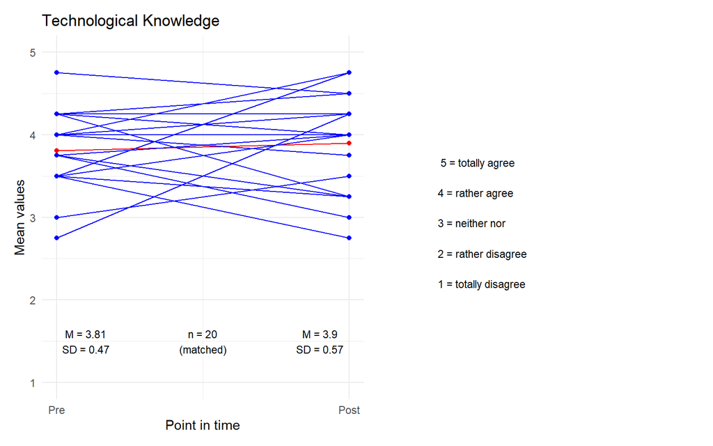

```r
ppp(dsw$TK_mean, dsw$t, dsw$PersonID.m, "Technological Knowledge", 1,5) + legende1_5
```

### Single Plots

```r
single_graph_vert <- function(Item, t, scale_length){

# 4 answer categories, else prepare function for 5 answer categories
if (scale_length == 4) {
labels_levels <- c("can't do this", " could find out how to do this", "can do this myself", "can teach others this")
one_X_list <- c(1:4)
}else{
labels_levels <- c("totally disagree", " rather disagree", "neither nor", " rather agree", " totally agree")
one_X_list <- c(1:5)
}
#trycatch here


# prepare strings according to the t parameter
if (t == "pre") {
label_prepost <- "Pre"
}else{
label_prepost <- "Post"
}
#trycatch here


# prepare descriptives & the data frame for plotting
df_graph <- Item
mean_plotting <- mean(df_graph[df_graph>0], na.rm = TRUE)
mean_rounded <- paste(" M =", format(round(mean_plotting, 2), nsmall = 2))
SD_plotting <- sd(df_graph[df_graph>0], na.rm = TRUE)
SD_rounded <- paste(" SD =", format(round(SD_plotting, 2), nsmall = 2))
n <- sum(!is.na(df_graph[df_graph>0]))
n_rounded <- paste(" N =", format(n))
annotation_complete <- paste("SD =", format(round(SD_plotting, 2), nsmall = 2), " " , "N =", n)


df_graph <- factor(df_graph, levels = one_X_list, labels = labels_levels)
frequency <- 0.4*prop.table(table(df_graph))
h.data <- data.frame(Ort=one_X_list, constant = t, gross = frequency)

# plotting

ggplot(data = h.data, aes(Ort, constant, text = annotation_complete))+
geom_linerange(data = h.data, aes(x = Ort, ymin = 1-gross.Freq, ymax = 1+gross.Freq), colour='#0078A5', linewidth = 5) +
scale_x_discrete(name = NULL, limits=one_X_list, labels = one_X_list) +
scale_y_discrete(name = label_prepost) +
geom_linerange(data = h.data, aes(x = mean_plotting, ymin = 1-0.3, ymax = 1+0.3), colour= "red", linewidth = 1) +
theme_minimal()+
theme(legend.position="none", aspect.ratio = 1.5)+
guides(size= "none", labels = "none")+
theme(axis.ticks = element_blank(),
      panel.grid.major.x = element_blank(),
      axis.ticks.y = element_blank(),
      axis.title.y = element_blank(),
      axis.text.x = element_blank())+

  geom_text(aes(x = mean_plotting, y = constant), label = SD_rounded, nudge_y = 0.385, nudge_x = -0.135, size = 2.5, colour = "black")+

  geom_text(aes(x = 0.5, y = 1), label = n_rounded, size = 2.5, colour = "black")+

  geom_text(aes(x = mean_plotting, y = constant), label = mean_rounded, nudge_y = 0.40, nudge_x = 0.02, size = 2.5, fontface = "plain", colour = "red") +

coord_flip()
}
```

```r
single_graph_hori <- function(dv){

  df_graph <- dv

dv_label <- strsplit(attributes(df_graph)$comment, ": ")[[1]][2]

mean_plotting <- mean(df_graph[df_graph>0], na.rm = TRUE)
mean_rounded <- paste(" M =", format(round(mean_plotting, 2), nsmall = 2))

SD_plotting <- sd(df_graph[df_graph>0], na.rm = TRUE)
SD_rounded <- paste(" SD =", format(round(SD_plotting, 2), nsmall = 2))

n <- sum(!is.na(df_graph[df_graph>0]))
n_rounded <- paste(" N =", format(n))

annotation_complete <- paste("SD =",
format(round(SD_plotting, 2), nsmall = 2), "                " , "N =",
n)

df_graph <- factor(df_graph, levels = c(1:5,-9), labels =
                c("totally disagree", " rather disagree", "neither nor", " rather agree", " totally agree", "not answered"))

frequency <- 0.4*prop.table(table(df_graph))

h.data <- data.frame(Ort=1:6, constant = dv_label, gross = frequency)

ggplot(data = h.data, aes(Ort, constant,text = annotation_complete))+
   geom_linerange(data = h.data, aes(x = Ort, ymin = 1-gross.Freq, ymax = 1+gross.Freq), colour=c(rep(c('#0078A5','#8CD000'),c(5,1))),
              linewidth = 5) +
   scale_x_discrete(name="") +
   scale_y_discrete(name="", labels = function(x) str_wrap(str_replace_all(x, "foo" , " "),
                                                 width = 30))+

   geom_linerange(data = h.data, aes(x = mean_plotting, ymin = 1-0.43, ymax = 1+0.43), colour= "red", linewidth = 1) +
             theme_minimal()+
             theme(legend.position="none")+
             guides(size= "none", labels = "none")+
             theme(axis.ticks = element_blank())+

   geom_text(aes(x = 4, y = 0.5),
             label = SD_rounded,
             size = 2,
             colour = "black")+

   geom_text(aes(x = 5, y= 0.5),
             label = n_rounded,
             size = 2,
             colour = "black")+

   geom_text(aes(x = mean_plotting, y = constant),
             label = mean_rounded,
             nudge_y = 0.5,
             size = 2,
             fontface = "plain",
             colour = "red")
}
```

> Two versions of this graph exist:
> - a vertical bar chart, which is also used in generating the pre-post single plot. It also displays whether the data is from pre or post.

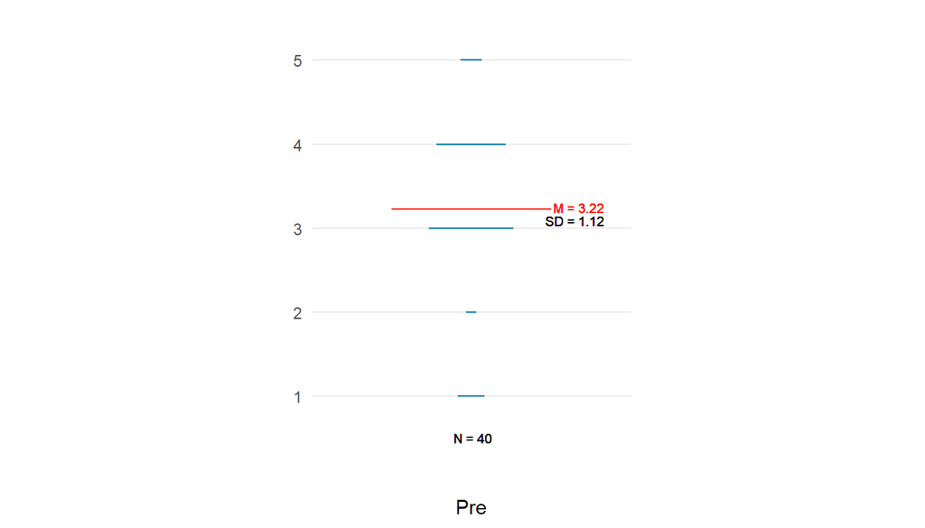

```r
single_graph_vert(dsw$TK1, "pre", 5)
```

> - and a horizontal bar chart that has been used in older versions of the evaluation process and can currently not be used to generate pre-post single plots.

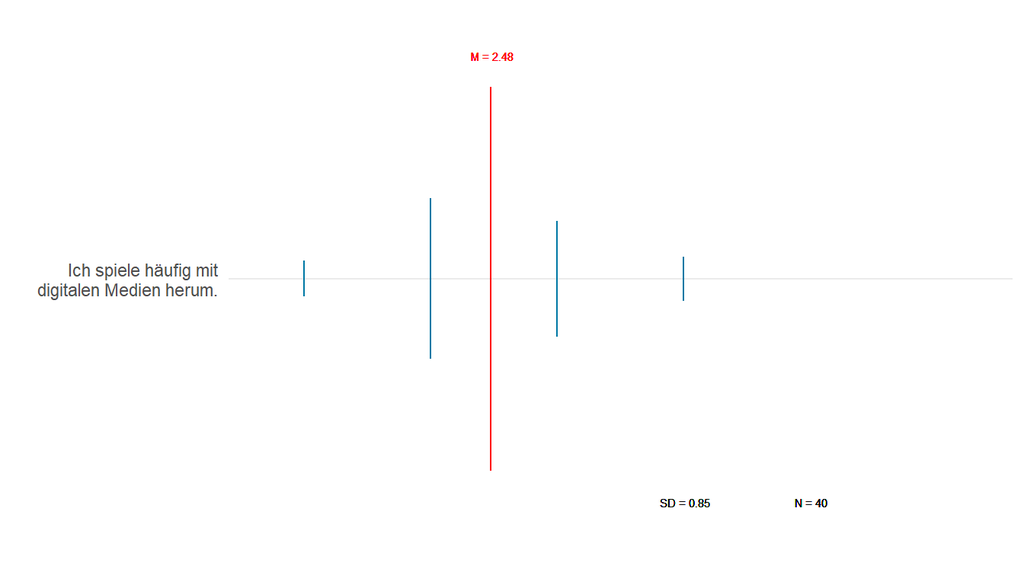

```r
single_graph_hori(dsw$TK2)
```

### Pre-Post Single Plot

> To show the values of the individual items of the scales at both pre and post, two functions are used:
> - Mean and standard deviation are calculated for each measurement point and plotted as a bar chart, as can be seen in the two plots above. The red line signs the mean value of the item.
> - In a second step, the two graphs are combined with the package “patchwork” and labels based on the respective item’s attributes() are added.

```r
patching_single_graphs <- function(Item, time_var, pre_val, post_val, scale_length){
# initiate empty lists
data_graph_pre_t0 <- vector(mode = "list", length = 0)
data_graph_pre_t1 <- vector(mode = "list", length = 0)

# 4 answer categories, else prepare function for 5 answer categories
if (scale_length == 4) {
data_graph_pre_t0$Four <- Item[time_var == pre_val]
data_graph_pre_t1$Four <- Item[time_var == post_val]
plot1 <- single_graph_vert(data_graph_pre_t0$Four, "pre", scale_length)
plot2 <- single_graph_vert(data_graph_pre_t1$Four, "post", scale_length)
}else{
data_graph_pre_t0$Five <- Item[time_var == pre_val]
data_graph_pre_t1$Five <- Item[time_var == post_val]
plot1 <- single_graph_vert(data_graph_pre_t0$Five, "pre", scale_length)
plot2 <- single_graph_vert(data_graph_pre_t1$Five, "post", scale_length)
}

# use the patchwork() package to edit plots & then combine them
patches = plot1 + plot2 + plot_layout(widths = c(1,1)) + plot_annotation(
title = attributes(Item)$comment, theme = theme(plot.title = element_text(size = 14)))
patches[[2]] = patches[[2]] + theme(axis.text.y = element_blank(),
axis.ticks.y = element_blank(),
axis.title.y = element_blank(),
axis.text.x = element_blank())
patches[[1]] = patches[[1]] + theme(axis.text.x = element_blank())
patches
}
```

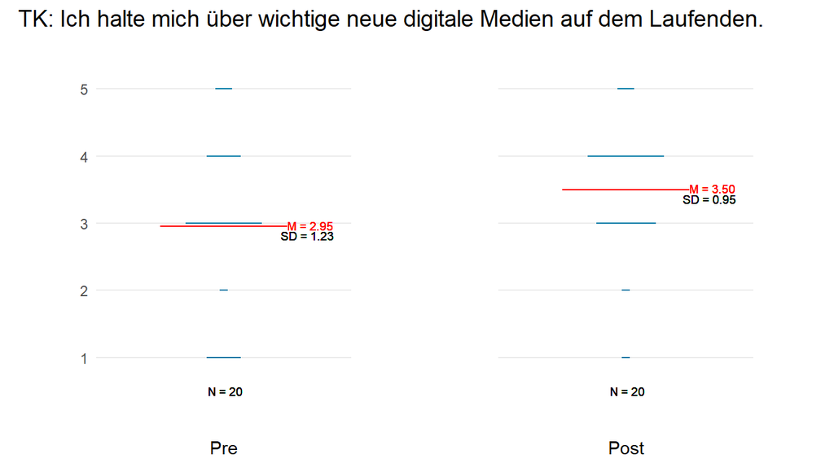

```r
patching_single_graphs(dsw$TK1, dsw$t, 0, 1, 5)
```

## References

Correll, Michael, and Michael Gleicher. 2014. “Error Bars Considered Harmful: Exploring Alternate Encodings for Mean and Error.” *IEEE Transactions on Visualization and Computer Graphics* 20 (12): 2142–51. https://doi.org/10.1109/TVCG.2014.2346298.

Schmidt, Denise A., Evrim Baran, Ann D. Thompson, Punya Mishra, Matthew J. Koehler, and Tae S. Shin. 2009. “Technological Pedagogical Content Knowledge (TPACK).” *Journal of Research on Technology in Education* 42 (2): 123–49. https://doi.org/10.1080/15391523.2009.10782544.

Vetterlein, Anja, and Erik Sengewald. 2015. “Ergebnisdarstellung in Der Lehrveranstaltungsevaluation: Effekte Verschiedener Berichte Auf Die Qualität von Lehrveranstaltungen.” *Diagnostica* 61 (3): 153–62. https://doi.org/10.1026/0012-1924/a000128.